# Python for Unstructured Data Analysis

### 2018.10.15 Hanyang University

# Keywords

## - 숫자형과 문자열 다루기

## - 리스트(list), 튜플(tuple), 딕셔너리(dictionary), 집합(set), 어레이(array), 그리고 자료형 간 변환

## - 비교, 조건, 불(booleans)

## - 파일 읽고 쓰기 : 피클(pickle), Text데이터 읽고 쓰기

## - Graph 자료구조

## - Graph 자료구조 기반 기초 알고리즘

# Jupyter Notebook에서 Markdown 다루기

## 1. 제목 달기 / 밑줄 긋기 / 들여쓰기

# Heading 1

## Heading 2

### Heading 3

## 2. LaTex(수식 쓰기)

$$e^x=\sum_{i=0}^\infty \frac{1}{i!}x^i$$

$e^{i\pi} + 1 = 0$

$$ \mathbf{V}_1 \times \mathbf{V}_2 = \begin{vmatrix} \mathbf{i} & \mathbf{j} & \mathbf{k} \\ \frac{\partial X}{\partial u} & \frac{\partial Y}{\partial u} & 0 \\ \frac{\partial X}{\partial v} & \frac{\partial Y}{\partial v} & 0 \end{vmatrix} $$

## 3. 표 만들기

|  | I | play | tennis |
| --- | --- | --- | --- |
| "I play tennis." | 1 | 1 | 1 |
| "I play." | 1 | 1 | 0 |
| "I, I play." | 1 | 1 | 0 |

- markdown 표만들기를 도와주는 도구 :  
  http://www.tablesgenerator.com/markdown_tables

## 4. 줄나누기 / 강조하기

The apparent complexity of its behavior over time is largely a reflection of the complexity of the environment in which it finds itself.  
........................................................  
**At the level of cells or molecules ants are demonstrably complex,**  
*but these microscopic details of the inner environment may be largely irrelevant to the ant’s behavior in relation to the outer environment.*

## 5. 프로그램 코드 예쁘게 집어 넣기

- 파이썬 문법

  ```
  def f(x):
    return x**2
  ```

- C++ 문법

  ```
  if (i=0; i<n; i++) {
  printf("hello %d\n", i);
  x += 4;
  }
  ```

### **! 수식, 코딩, 출력물, 설명 문서를 한번에 다루면 효율이 높아집니다. !**

# 1. 숫자형 자료와 연산

```python
x = 14
y = 3

print("x+y :", x+y)
print("x-y :", x-y)
print("x*y :", x*y)
print("x/y :", x/y)
print("round(x/y, 2) :", round(x/y, 2) ,"=> 소숫점 2째자리 반올림")
print("x**y :", x**y ,"=> x의 y승")
print("x//y :", x//y ,"=> x/y의 정수부분")
print("x%y :", x%y ,"=> x/y의 나머지, 짝수/홀수 여부 확인 시 유용")
```

```
x+y : 17
x-y : 11
x*y : 42
x/y : 4.666666666666667
round(x/y, 2) : 4.67 => 소숫점 2째자리 반올림
x**y : 2744 => x의 y승
x//y : 4 => x/y의 정수부분
x%y : 2 => x/y의 나머지, 짝수/홀수 여부 확인 시 유용
```

```python
# 파이썬 특유의 연산 표시 : 다른 사람들의 코드를 읽어야할 경우가 있습니다.
x = 14
print("x : " ,x)
x += 1    # x에 1을 더합니다. 순차적으로 1씩 더할때 이용합니다.
print("x += 1 :" ,x)
x -= 4    # x에서 4를 뺍니다.
print("x -= 4 : " ,x)
x *= -2.6 # x에 -2.6을 곱합니다.
print("x *= -2.6 :",x)
x /= 5*y  # x를 y에 5를 곱한 숫자로 나눕니다.
print("x /= 5*y:" , x)
x //= 3.4 # x를 3.4로 나눈 후 반올림합니다.
print("x //= 3.4:" ,x)
```

```
x :  14
x += 1 : 15
x -= 4 :  11
x *= -2.6 : -28.6
x /= 5*y: -1.9066666666666667
x //= 3.4: -1.0
```

```python
# 숫자 연산을 사용자의 입력을 받아 실행해 봅시다.

# 높이 (h)에서 공을 떨어뜨렸을 때 시간 (t) ms가 걸렸습니다. 공의 지름은 얼마일까요?

G = 9.81 # 지구에서 중력가속도, 상수는 따로 빼내어 할당하는 습관.
h = float(input("Enter the height of the tower: "))
t = float(input("Enter the time interval: "))
s = (G*t**2)/2
print("The height of the ball is", h-s, "meters")
```

```
Enter the height of the tower: 100
Enter the time interval: 1
The height of the ball is 95.095 meters
```

- 연습문제  
  x = 14, y = 3 일때, 파이썬으로 x/y의 나머지를 %연산자를 사용하지 않고 구해보시오.

# 2. 문자형 자료와 연산

## 1) 인코딩(Encoding) & 디코딩(Decoding)

### 어렵고 또 어렵지만 Text Mining을 위한 데이터 전 처리시 겪어야만 하는 고난

### 유니코드(Unicode) 인코딩:

#### - 컴퓨터는 결국 0,1 이라는 값만 인식할 수 있음.

#### - 컴퓨터가 문자열을 처리할 수 있도록 문자를 숫자로 매핑, 표준화 시도(아스키:ASCII)

#### - ASCII는 127개의 문자만 처리할 수 있는데, 이는 영어와 같은 알파벳만 처리 가능

#### - 유니코드는 모든 언어를 표현할 수 있도록 넉넉하게 매핑 설계, 특히 문자열을 표현하는데 2~3byte가 필요한 한글 표현.(영어 알파벳은 1개 문자열에 1byte)

#### - 유니코드 매핑 규칙 아래 여러 변종이 생겼는데 utf-8이 대표적. 최근 개발은 utf-8을 표준으로 하는 경우가 많음.

#### - Window 기본 인코딩이 cp949로 되는 경우가 많으니 주의 필요.

| 인코딩 | 특징 | 위키디피아 |
| --- | --- | --- |
| EUC-KR | 한글완성형 | https://ko.wikipedia.org/wiki/EUC-KR |
| CP949 | 한글완성형(MS사) | https://ko.wikipedia.org/wiki/CP949 |
| UTF-8 | 유니코드8비트(한글1글자에 3바이트) | https://ko.wikipedia.org/wiki/UTF-8 |

```python
a = "노벨경제학상 수상자 폴 로머(paul Romer)는 차터시티(charter city)를 제안했다."
print(type(a))

# 인코딩 : 컴퓨터가 처리할 수 있는 형태로 변환
u8 = a.encode('utf-8')
print(type(u8))
print(u8)

print('-------------------------------------')

cp = a.encode('cp949')
print(type(cp))
print(cp)

print('-------------------------------------')

obt = "paul".encode('ascii')
print(type(obt))
print(obt)
```

```
<class 'str'>
<class 'bytes'>
b'\xeb\x85\xb8\xeb\xb2\xa8\xea\xb2\xbd\xec\xa0\x9c\xed\x95\x99\xec\x83\x81 \xec\x88\x98\xec\x83\x81\xec\x9e\x90 \xed\x8f\xb4 \xeb\xa1\x9c\xeb\xa8\xb8(paul Romer)\xeb\x8a\x94 \xec\xb0\xa8\xed\x84\xb0\xec\x8b\x9c\xed\x8b\xb0(charter city)\xeb\xa5\xbc \xec\xa0\x9c\xec\x95\x88\xed\x96\x88\xeb\x8b\xa4.'
-------------------------------------
<class 'bytes'>
b'\xb3\xeb\xba\xa7\xb0\xe6\xc1\xa6\xc7\xd0\xbb\xf3 \xbc\xf6\xbb\xf3\xc0\xda \xc6\xfa \xb7\xce\xb8\xd3(paul Romer)\xb4\xc2 \xc2\xf7\xc5\xcd\xbd\xc3\xc6\xbc(charter city)\xb8\xa6 \xc1\xa6\xbe\xc8\xc7\xdf\xb4\xd9.'
-------------------------------------
<class 'bytes'>
b'paul'
```

```python
# 디코딩 : 사람이 읽을 수 있는 형태로 변환
du8 = u8.decode('utf-8')
print(type(du8))
print(du8)

print('-------------------------------------')

dcp = u8.decode('cp949')
print(type(dcp))
print(dcp)
```

```
<class 'str'>
노벨경제학상 수상자 폴 로머(paul Romer)는 차터시티(charter city)를 제안했다.
-------------------------------------
```

```
---------------------------------------------------------------------------
UnicodeDecodeError                        Traceback (most recent call last)
<ipython-input-5-f65f57a61743> in <module>()
      6 print('-------------------------------------')
      7
----> 8 dcp = u8.decode('cp949')
      9 print(type(dcp))
     10 print(dcp)

UnicodeDecodeError: 'cp949' codec can't decode byte 0xeb in position 0: illegal multibyte sequence
```

```python
# bytes로부터 인코딩 알아내기
import chardet
print(chardet.detect(cp))
print(chardet.detect(u8))
print(chardet.detect(obt))
```

```
{'language': 'Korean', 'encoding': 'EUC-KR', 'confidence': 0.99}
{'language': '', 'encoding': 'utf-8', 'confidence': 0.99}
{'language': '', 'encoding': 'ascii', 'confidence': 1.0}
```

## 인코딩 관련 문제를 겪지 않기 위한 프로세스

### - 주고 받는 파일의 인코딩을 통일한다. (ex : UTF-8)

### - 프로세스의 첫 단계에서 입력 받은 바이트 문자열을 유니코드 문자열로 디코딩한다.

### - 디코딩된 문자열 상태에서 자료처리를 한다.

### - 처리된 자료는 통일된 인코딩으로 파일로 저장한다.(ex : UTF-8)

1. utf-8로 작성된 파일 읽기

   ```
   import codecs
   with codecs.open('utf8.txt', encoding='utf8', mode = 'r') as f:
        data = f.read()  # 유니코드 문자열
   ```

2. unicode 문자열로 프로그램 수행하기

   ```
   data = function(data)
   ```

3. utf-8로 수정된 문자열 저장하기

   ```
   with open('func_utf8.txt', encoding='utf8', mode='w') as f:
        f.write(data)
   ```

#### - source code 인코딩

source code(.py 파일)도 문자로 이루어진 파일임으로 인코딩 타입이 필요하다. 파이썬3.0부터는 기본 Default로 설정되어 있으나 다른 사람이 짠 옛 코드에는 다른 인코딩이 나타날 수 있다. source code 인코딩은 source파일 첫 줄에  
# -- coding: utf-8 -*-  
로 표시하여 지정한다.

## 2) 문자열 처리에 대해 알아둘만한 사항

### 문자열 안에 변수 넣기

```python
print("1.정수형 넣기")
print("I ate %d apples." % 3)
print("2.문자열 넣기")
print("I ate %s apples." % "five")
print("3.정수형 변수 넣기")
number = 3
print("I eat %d apples." % number)
print("4.2개 이상의 변수 넣기")
number = 10
day = "three"
print("I ate %d apples. so I was sick for %s days." % (number, day))
print("4.소숫점 변수 넣기")
import math
print("The value of pi is %0.2f." % math.pi)
```

```
1.정수형 넣기
I ate 3 apples.
2.문자열 넣기
I ate five apples.
3.정수형 변수 넣기
I eat 3 apples.
4.2개 이상의 변수 넣기
I ate 10 apples. so I was sick for three days.
4.소숫점 변수 넣기
The value of pi is 3.14.
```

### 문자열 관련 함수

```python
print("1.문자 갯수 세기")
print("infinity".count('in'))

print("2.문자열 양쪽 공백 지우기")
print("  infinity  ".strip())

print("3.문자열 바꾸기")
print("infinity".replace("inf","def"))

print("4.문자열 나누기")
print("infinity".split("ni"))

print("5.슬라이싱으로 문자열 나누기")
print("infinity"[0])
print("infinity"[:2])
print("infinity"[2:])
print("infinity"[3:5])
print("infinity"[-2:])
print("infinity"[:-2])
```

```
1.문자 갯수 세기
2
2.문자열 양쪽 공백 지우기
infinity
3.문자열 바꾸기
definity
4.문자열 나누기
['infi', 'ty']
5.슬라이싱으로 문자열 나누기
i
in
finity
in
ty
infini
```

# 3. 파이썬 자료구조 및 문법

### 1) Booleans & Assignment & Comparisons & Conditional expression

```python
print(5 == 4)
print(4 == 4)
print(4 > 4)
print(4 < 4)
print(4 <= 4)
print(7 >= 9)
print(7 != 9)
print(type((7 != 9)))
```

```
False
True
False
False
True
False
True
<class 'bool'>
```

```python
x = 5+4
y = 2*x
print(y)

print(2**(y+1/2) if x+10 < 0 else 2**(y-1/2))

if x+10 < 0 :
    print(2**(y+1/2))
else :
    print(2**(y-1/2))
```

```
18
185363.80004736633
185363.80004736633
```

### 2) 집합(Sets) : {1,2} 중복과 순서가 없다.

```python
# 문자열의 중복을 제거하거나 unique한 단어의 수, 특정 단어의 포함여부 등을 확인할 때 사용
set1 = {1+2, 3, 4}
set2 = {3, 4, 1+2}
print(set1)
print(set2)
print(sum(set1))
print(len(set1))

S = {1,2,3}
print(2 in S)
print(7 in S)

#Union
U = set1 | S
print(U)

#Intersetion
I = set1 & S
print(I)

#변형하기
U.add(20)
print(U)
U.remove(3)
print(U)
U.update({40,50})
print(U)
```

```
{3, 4}
{3, 4}
7
2
True
False
{1, 2, 3, 4}
{3}
{1, 2, 3, 4, 20}
{1, 2, 4, 20}
{1, 2, 50, 4, 20, 40}
```

```python
Z = U
print(Z)
Z.remove(4)
print(Z, U)
# U에서도 4가 삭제된다. Python은 1개의 copy data structure를 저장한다.
```

```
{1, 2, 50, 4, 20, 40}
{1, 2, 50, 20, 40} {1, 2, 50, 20, 40}
```

```python
T = U.copy()
T.add(90)
print(U, T)
# copy를 이용하면 T에는 90이 추가되었으나 U에는 추가되지 않았다.
```

```
{1, 2, 50, 20, 40} {1, 2, 40, 50, 20, 90}
```

```python
comp_set1 = {2*x for x in {1,2,3}}
print(comp_set1)

comp_set2 = {x*x for x in {1,2} | {1,2,3}  if x > 2}
print(comp_set2)

comp_set3 = {x*y for x in {1,2} for y in {1,2,3} if x!=y}
print(comp_set3)

empty_set4 = {x*x for x in {1,2} | {1,2,3}  if x > 4}
print(empty_set4)

error_set_in_set = {{1,3}, 3}
```

```
{2, 4, 6}
{9}
{2, 3, 6}
set()
```

```
---------------------------------------------------------------------------
TypeError                                 Traceback (most recent call last)
<ipython-input-14-410c06ec8fff> in <module>()
     11 print(empty_set4)
     12
---> 13 error_set_in_set = {{1,3}, 3}

TypeError: unhashable type: 'set'
```

```python
{1,2,3}[0]
```

```
---------------------------------------------------------------------------
TypeError                                 Traceback (most recent call last)
<ipython-input-15-71bf5e044980> in <module>()
----> 1 {1,2,3}[0]

TypeError: 'set' object does not support indexing
```

### 3) 리스트(list) : [1,2] 가장 많이 쓰이는 자료구조

```python
a = list()
print(a)

b = [[1,1+1,4-2], {2*2, 5, 6}, "python"]
print(b)

c = [1,2,3] + ["my word"]
print(c)

c.append(b)
print(c)
```

```
[]
[[1, 2, 2], {4, 5, 6}, 'python']
[1, 2, 3, 'my word']
[1, 2, 3, 'my word', [[1, 2, 2], {4, 5, 6}, 'python']]
```

```python
# list comprehensions
print([2*x for x in {2,1,3,4,5}])
print([2*x for x in [2,1,3,4,5]])
print([x*y for x in [2,1,3,4,5] for y in [10,20,30]])
print([[x,y] for x in ['A','B','C'] for y in [1,2,3]])
```

```
[2, 4, 6, 8, 10]
[4, 2, 6, 8, 10]
[20, 40, 60, 10, 20, 30, 30, 60, 90, 40, 80, 120, 50, 100, 150]
[['A', 1], ['A', 2], ['A', 3], ['B', 1], ['B', 2], ['B', 3], ['C', 1], ['C', 2], ['C', 3]]
```

```python
L = [x*10 for x in range(1,9)]
print(L)
print(L[5:]) # 위치 5부터 그 다음
print(L[:5]) # 위치 5부터 마지막까지 제외
print(L[3:5]) # 위치 3부터 위치 5부터 마지막까지 제외
print(L[::2]) # 처음부터 매 2번째 마다
print(L[1::2])# 위치 1에서부터 매 2번째 마다
print(L[:-2]) # 마지막에서 출발하여 위치 2
print(L[-2:]) # 마지막 2에서 출발하여 나머지
print(L[::-1]) # 마지막에서부터 전체
```

```
[10, 20, 30, 40, 50, 60, 70, 80]
[60, 70, 80]
[10, 20, 30, 40, 50]
[40, 50]
[10, 30, 50, 70]
[20, 40, 60, 80]
[10, 20, 30, 40, 50, 60]
[70, 80]
[80, 70, 60, 50, 40, 30, 20, 10]
```

```python
list_of_list = [[1,1],[2,4],[3,9]]
flat_list = [x for sublist in list_of_list for x in sublist]
print(flat_list)

unpack_list = [y for [x,y] in list_of_list]
print(unpack_list)

import numpy as np
np_array = np.array(list_of_list)
print(np_array)
```

```
[1, 1, 2, 4, 3, 9]
[1, 4, 9]
[[1 1]
 [2 4]
 [3 9]]
```

### 4) 튜플(tuple) : (1,2) 원소의 삭제, 변경이 안된다.

```python
my_tuple = ("A","B","C")
print(my_tuple[0])

unpack_tuple = [y for (x,y) in [(1,'A'),(2,'B'),(3,'C')]]
print(unpack_tuple)

print(list(zip([1,2,3],[4,5,6])))
characters = ['Neo', 'Morpheus', 'Trinity']
actors = ['Keanu', 'Laurence', 'Carrie-Anne']
print(set(zip(characters, actors)))
```

```
A
['A', 'B', 'C']
[(1, 4), (2, 5), (3, 6)]
{('Trinity', 'Carrie-Anne'), ('Morpheus', 'Laurence'), ('Neo', 'Keanu')}
```

```python
# tuple comprehesions is NOT a tuple, IT's a generator
print((i for i in [1,2,3]))
print([i for i in [1,2,3]])
print(list(i for i in [1,2,3]))
```

```
<generator object <genexpr> at 0x108638938>
[1, 2, 3]
[1, 2, 3]
```

### 5) Python Comprehension :

iterable한 오브젝트를 생성하기 위한 방법 중 하나

#### -List comprehension

#### -Set comprehension

#### -Dictionary comprehension

#### -Generator Expression : 한번에 모든 원소를 반환하지 않고, 한번에 하나의 원소만 반환하는 generator를 생성한다.

https://mingrammer.com/introduce-comprehension-of-python/

### 6) 딕셔너리(Dictionary) : {Key1:Value1, Key2:Value2 ...}

```python
# dictionary는 Key로 indexing 한다.
# Key는 중복이 없어야 한다.

my_dict = {'Neo' : 40000, 'Thanos' : 100000}
print(my_dict['Neo'])

my_dict['Iron Man'] = 200000
print(my_dict)
print(my_dict.keys())
print(my_dict.values())
print(my_dict.items())
print([x for x in my_dict.items()])
print([k + "'s power level : " + str(v) for (k,v) in my_dict.items()])
```

```
40000
{'Neo': 40000, 'Thanos': 100000, 'Iron Man': 200000}
dict_keys(['Neo', 'Thanos', 'Iron Man'])
dict_values([40000, 100000, 200000])
dict_items([('Neo', 40000), ('Thanos', 100000), ('Iron Man', 200000)])
[('Neo', 40000), ('Thanos', 100000), ('Iron Man', 200000)]
["Neo's power level : 40000", "Thanos's power level : 100000", "Iron Man's power level : 200000"]
```

```python
key_list = ['A', 'B', 'C']
value_list = [1, 2, 3]
new_dict = dict(zip(key_list, value_list))
print(new_dict)
```

```
{'B': 2, 'A': 1, 'C': 3}
```

```python
print([2*x for x in {4:'a', 3:'b'}.keys()])
print([x+'c' for x in {4:'a', 3:'b'}.values()])
print([k for k in {'a':1, 'b':2}.keys() | {'b':3, 'c':4}.keys()])
print([k for k in {'a':1, 'b':2}.keys() & {'b':3, 'c':4}.keys()])
```

```
[6, 8]
['bc', 'ac']
['a', 'c', 'b']
['b']
```

# 4. 파일 읽고 쓰기

### 1) 이쯤에서 메모리에 담겨 있는 변수들을 확인해 봅시다.

```python
whos
```

```
Variable       Type       Data/Info
-----------------------------------
G              float      9.81
I              set        {3}
L              list       n=8
S              set        {1, 2, 3}
T              set        {1, 2, 40, 50, 20, 90}
U              set        {1, 2, 50, 20, 40}
Z              set        {1, 2, 50, 20, 40}
a              list       n=0
actors         list       n=3
b              list       n=3
c              list       n=5
characters     list       n=3
chardet        module     <module 'chardet' from '/<...>ges/chardet/__init__.py'>
comp_set1      set        {2, 4, 6}
comp_set2      set        {9}
comp_set3      set        {2, 3, 6}
cp             bytes      b'\xb3\xeb\xba\xa7\xb0\xe<...>xbe\xc8\xc7\xdf\xb4\xd9.'
day            str        three
du8            str        노벨경제학상 수상자 폴 로머(paul Rome<...>차터시티(charter city)를 제안했다.
empty_set4     set        set()
flat_list      list       n=6
h              float      100.0
key_list       list       n=3
list_of_list   list       n=3
math           module     <module 'math' from '//an<...>3.5/lib-dynload/math.so'>
my_dict        dict       n=3
my_tuple       tuple      n=3
new_dict       dict       n=3
np             module     <module 'numpy' from '//a<...>kages/numpy/__init__.py'>
np_array       ndarray    3x2: 6 elems, type `int64`, 48 bytes
number         int        10
obt            bytes      b'paul'
s              float      4.905
set1           set        {3, 4}
set2           set        {3, 4}
t              float      1.0
u8             bytes      b'\xeb\x85\xb8\xeb\xb2\xa<...>xed\x96\x88\xeb\x8b\xa4.'
unpack_list    list       n=3
unpack_tuple   list       n=3
value_list     list       n=3
x              int        9
y              int        18
```

```python
del(G,I,s)
```

```python
all = [var for var in globals() if var[0] != "_"]
for var in all:
    del globals()[var]
```

### 2) 텍스트 파일 읽고 쓰기

```python
import os
import glob
import codecs

floc = '/Users/hanjudong/work/W2018_HYU_PYTHON'
econ_flist = glob.glob(floc+'/econ_nobel/*.txt')
phys_flist = glob.glob(floc+'/phys_nobel/*.txt')
```

```python
def doctolist(flst, file, category):
    doclist = [category]
    with codecs.open(file, 'r' , encoding='utf-8', errors='ignore') as f:
        doclist.append(file.replace(".txt","").replace(floc,""))
        data = [f.read().lower()]
        doclist.append(data[0])
    return doclist
```

```python
econ_txt = (
 [doctolist(econ_flist, file, 'econ_nobel') for file in econ_flist]
)

phys_txt = (
 [doctolist(econ_flist, file, 'phys_nobel') for file in econ_flist]
)
```

```python
to_write = econ_txt[0][0]
print(to_write)
```

```
econ_nobel
```

```python
with open(floc+'/test_write.txt', 'w') as t:
    t.write(to_write)
```

```python
!cat /Users/hanjudong/work/W2018_HYU_PYTHON/test_write.txt
```

```
econ_nobel
```

```python
# 추가 모드로 쓰기, with 를 빼면 close() 로 파일을 닫아줘야함.
a = open(floc+'/test_write.txt', 'a')
for i in range(1,3):
    if i == 1 :
        data = "\n%d번째 줄에 자료를 추가합니다. \n" % (i+1)
    else :
        data = "%d번째 줄에 자료를 추가합니다. \n" % (i+1)
    a.write(data)
a.close()
```

```python
!cat /Users/hanjudong/work/W2018_HYU_PYTHON/test_write.txt
```

```
econ_nobel
2번째 줄에 자료를 추가합니다.
3번째 줄에 자료를 추가합니다.
```

### 참고

excel 파일을 읽고 쓰는 것은 xlrd, ,openpyxl, xlwt 등을 알아보고 활용해 봅시다.

http://www.python-excel.org/

### 3) Pickle : 파이썬 고유의 자료형을 그대로 저장하고 불러온다.(str로 처리하지 않고)

```python
import pickle
list = ['a', 'b', 'c']
with open ('test_pickle.txt', 'wb') as f:
    pickle.dump(list, f)

with open ('test_pickle.txt', 'rb') as r:
    back_list = pickle.load(r)
print(back_list)
```

```
['a', 'b', 'c']
```

# 5. Graph

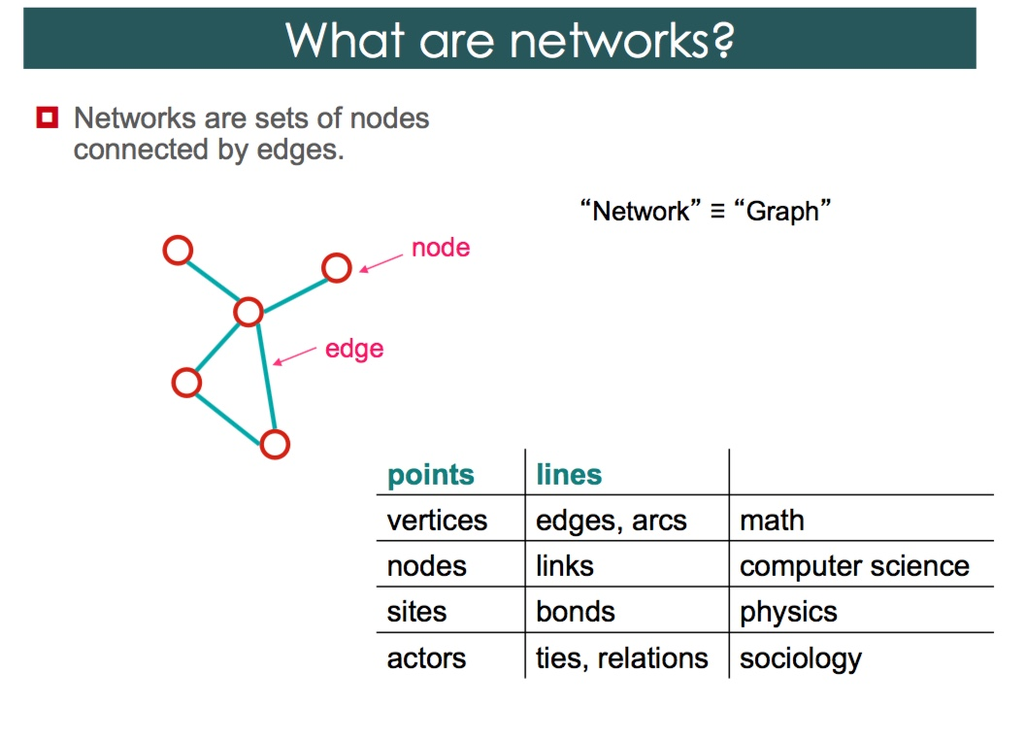

```python
from IPython.display import Image
Image(filename='sn.jpeg')
```

[figure not shown]

```python
Image(filename='Nbooks.jpeg')
```

[output not shown]

```python
import networkx as nx
G = nx.read_gexf('LesMiseables.gexf')
```

```python
G.nodes(data=True)
```

[output not shown]

[output cut: 407 more lines]

[output not shown]

```python
# 이름(Label)을 알때 Node ID를 찾기
for i in range(len(G.nodes())):
    if G.nodes(data=True)[i][1]['label'] == 'Valjean':
        print(G.nodes(data=True)[i][0])

# Node ID를 알때 이름(Label)을 찾기
for i in range(len(G.nodes())):
    if G.nodes(data=True)[i][0] == '11':
        print(G.nodes(data=True)[i][1]['label'])
```

```
11
Valjean
```

```python
G.edges(data=True)[1]
```

```
('42', '41', {'id': '99', 'weight': 2.0})
```

```python
node_class = {G.nodes(data=True)[i][0] : int(G.nodes(data=True)[i][1]['Modularity Class']) for i in range(len(G.nodes()))}
node_label = {G.nodes(data=True)[i][0] : G.nodes(data=True)[i][1]['label'] for i in range(len(G.nodes()))}
node_size = {G.nodes(data=True)[i][0] : 25*G.nodes(data=True)[i][1]['viz']['size'] for i in range(len(G.nodes()))}
```

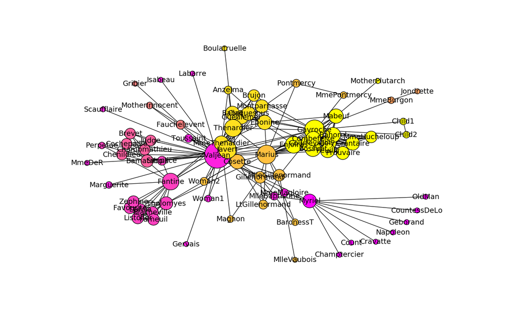

```python
import matplotlib.pyplot as plt
plt.figure(figsize=(13,8), dpi=80)
values = [node_class.get(node) for node in G.nodes()]
size = [node_size.get(node) for node in G.nodes()]
nx.draw(G, cmap = plt.get_cmap('spring'), node_color = values, node_size = size ,labels = node_label ,with_labels=True, font_size =14)
plt.show()
```

### 1) adjacency list

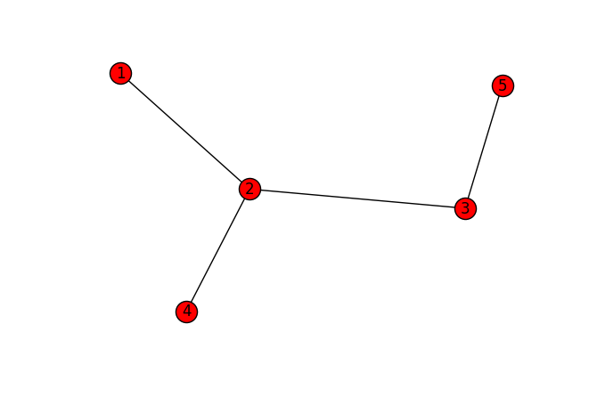

```
[(1, 2), (2, 3), (2, 4), (3, 5)]
```

```python
lines = ['1 2',
         '2 3 4',
         '3 5']
J = nx.parse_adjlist(lines, nodetype=int)
nx.draw(J, with_labels=True)
plt.show()
print(J.edges())
```

### 2) Adjacency Matrix

```python
A = nx.adjacency_matrix(J)
print(A.todense())
```

```
[[0 1 0 0 0]
 [1 0 1 1 0]
 [0 1 0 0 1]
 [0 1 0 0 0]
 [0 0 1 0 0]]
```

## 3) Centrality

### 어떠한 Node가 얼마나 상대적으로 중요한가?

## 1. Degree Centrality : the fraction of nodes it is connected to

## 2. Eigenvector Centrality : each nodes have a score proportional to the sum of the scores of its neighbors

### - IDEA :

$${x_i}{'} = \sum_{j} A_{ij} x_j $$

### After t steps a vector of centralities $x(t)$ given by

$$x(t) = A^t x(0)$$

### Write $x(0)$ as a linear combination of the eigenvectors $v_i$ of the adjacency matrix $A$

$$x(0) = \sum_{i}c_{i}v_{i}$$

### Choice some appropriate(normalization) constants $c_i$

$$x(t) = A^t\sum_{i}c_{i}v_{i} = \sum_{i}c_{i}k^{t}_{i}v_{i} = k^{t}_{1}\sum_{i}c_{i} (\frac{k_i}{k_1})^{t}v_{i} $$

#### where

#### $k_i$ : eigenvalues of $A$

#### $k_1$ : the largest of eigenvalue of $A$

so, $\frac{k_i}{k_1} < 1$ for all $ i\neq 1 \Rightarrow t \rightarrow \infty $ , we get $x(t) \rightarrow c_{1}k^{t}_{1}v_{1}$

### $A \rightarrow k_1 $ Centrality $x$ satisfies

$$ Ax = k_1x$$

### Eigenvector Centrality $x_i$

$$ x_i = k^{-1}_{1}\sum_{j} A_{ij}x_{j}$$

### Node 4는 degree centrality는 Node5와 같지만 Node 2와 직접 연결되어 있어 eigenvalue centrality는 더 크다.

```python
dc = nx.degree_centrality(J)
print("degree_centrality :" , dc)
ec = nx.eigenvector_centrality_numpy(J)
print("eigenvector_centrality :" , ec)
```

```
degree_centrality : {1: 0.25, 2: 0.75, 3: 0.5, 4: 0.25, 5: 0.25}
eigenvector_centrality : {1: 0.35355339059327395, 2: 0.6532814824381883, 3: 0.4999999999999999, 4: 0.35355339059327373, 5: 0.2705980500730987}
```

# 5. 다루지 않았지만 알아두면 좋을 것들

### - 데이터 처리 : 정규표현식(regular expression), 에디터(Vim, Sublime, Emacs, Pycharm)

### - Graph : Breadth-Fisrt Search(너비우선탐색), Bepth-Fisrt Search(깊이우선탐색), Shortest Path(최단경로)

# 6. 연습

### - 노벨 물리학상/경제학상 수상 연설(phys_nobel, econ_nobel 폴더) txt 파일을 파이썬으로 읽어 들여오고,

### - pt_arrange.ipynb 파일을 참조하여

### 1) 품사별로 Tagging하고

### 2) 등장하는 전체 단어의 갯수를 세어본다.

### 3) 등장하는 전체 명사의 갯수를 세어본다.

### 4) 명사+명사 의 갯수를 세어본다.